# Hiding in the trees: Unmasking a cryptic genus of arboreal New Guinea frogs with phylogenetic taxonomy

Author

Allison R. Fisher, Ke Cao, Allen Allison, Bulisa Iova, and Marguerite A. Butler

Published

August 8, 2026

# Abstract

Additional Keywords: cryptic taxa; homoplasy; indo-pacific; morphology; new classification; new genera; phylogenetic nomenclature; phylogenetics

# Introduction

*Oreophryne* (Boettger, 1895) is the oldest and arguably the best studied genus of the hyperdiverse frog subfamily Asterophryinae (family Microhylidae). Although taxonomic instability is well known in the history of the subfamily Asterophryinae (reviewed in Rivera *et al.*, 2017; Hill *et al.*, 2022), *Oreophryne* seemed to be the exception. Well known for its arboreal morphology and lifestyle, the taxonomy of the genus *Oreophryne* as currently recognized has been stable over the past century. Recently it was discovered that the single large clade is, in fact, two independently evolved clades (reviewed in Hill *et al.*, 2022). A natural question is how did this happen and why did it remain undiscovered for so long? One obvious answer is that their morphology is remarkably similar (Figure 1). *Oreophryne* are conspicuously arboreal and account for nearly all arboreal species of Asterophryinae (Günther, Richards, & Iskandar, 2001; Menzies, 2006), inhabiting lowland to montane rain forest, although there is a small group of diminutive, high-elevation, grassland species, a few of which are terrestrial (Zweifel, Cogger, & Richards, 2005; Günther & Richards, 2012; Putri *et al.*, 2023). In short, *Oreophryne* are morphologically distinctive, consistent with their arboreal lifestyle, and appear in the field to be a natural group preserved by niche conservatism.

*Oreophryne* was united by a useful diagnostic character distinct from all other genera. Based on a pectoral anatomy with highly reduced and distinctly curved clavicles (Parker, 1934; Zweifel, 2003), hypothetical new species could be assigned to *Oreophryne*, and for modern studies, confirmed by phylogenetic analysis with other members of *Oreophryne*. Over the past 130 years the genus *Oreophryne* has grown to 75 currently recognized species, fully one-fifth of the total diversity of subfamily Asterophryinae and the largest of the ~16 genera (Hill *et al.*, 2022; Frost, 2024). *Oreophryne* as currently recognized has the largest geographic distribution in the subfamily (Hill *et al.*, 2023a), with species centered on mainland New Guinea and its offshore islands (Werner, 1898; Zweifel, 1956; Zweifel, Menzies, & Price, 2003,; Kraus & Allison, 2004; Kraus & Allison, 2009; Kraus, 2013; Frost, 2024), but ranging westward to distant oceanic islands (Müller, 1894; Boulenger, 1896; Ahl, 1933; Putri *et al.*, 2023) and northward to Indonesia (Boettger, 1895; Setiadi *et al.*, 2010; Günther, Iskandar, & Richards, 2023) and the Southern Philippines Islands (Alcala, 1986; Balinton & de la Seña, 2015).

The apparently reliable diagnostic character, however, has never been demonstrated to be a synapomorphy, and recent studies have not found evidence for monophyly (Zweifel *et al.*, 2005; Rivera *et al.*, 2017). Recently, Hill et. al (2022, 2023b) established that *Oreophryne* sensu lato represents two reciprocally monophyletic groups that are not sister taxa (Figure 2), temporarily labeled “*Oreophryne* A” and “*Oreophryne* B”. Furthermore, it is unknown whether it is possible to identify these groups with any morphological characters – there may in fact be no reliable diagnostic characters, rendering phylogenetic taxonomic definitions for each clade an imperative for evolutionary study. The aims of this study are to assess the phylogenetic position of the newly available type species of *Oreophryne* to name and describe the new genus, and to develop phylogenetic definitions for both clades in the context of the subfamily-level Asterophrinae phylogeny including representatives from all known genera. Furthermore, we analyze the morphological characteristics to assess whether morphological diagnosis is possible, and consider whether there are any additional features to assist collectors when identifying putative *Oreophryne* in the field (e.g., call type, geography, other characters), and discuss the implications of having misleading diagnostic characters for evolutionary studies. Inclusion of samples in molecular phylogenetics is not enough, and indeed it is necessary to include explicit tests of monophyly when proposing a new taxonomy.

#### Taxonomic History:

Boettger (1895) described the genus *Oreoprhyne* and the species *Oreophryne senckenbergiana* on the basis of three specimens from Halmahera Island, in the Maluku Archipelago west of New Guinea, that lacked procoracoids and had cartilaginous sterna. He also noted the presence of expanded finger and toe pads and transverse folds of skin in the palate. Parker (1934) noted that procoracoids were present, but were reduced and re-diagnosed the genus on the basis of this feature together with the presence of reduced clavicles, no omosternum, and a large cartilaginous sternum; all characters of the pectoral girdle and sternum. Zweifel (2003) noted that “the clavicles are tiny, slightly curved bones lying on (ventral to) the procoracoid cartilage and apart from the midline and the scapula.” On the basis of these features there are now 75 recognized species in the genus (Frost, 2024).

We note that *O. senckenbergiana* was synonymized (Parker, 1934) with *Microhyla achatina var. moluccensis* described by Peters & Doria (1878) from Bacan and Ternate islands, based on morphology and the taxon is currently known as *O. moluccensis*. While Parkerʻs (1934) methodology was standard at the time, genetic information has revealed that cryptic species are rampant in this group, with species readily separated by distance and oceanic barriers (Hill *et al.*, 2022, 2023b). Because *O. senckenbergiana* was described from Halmahera island, and Bacan and Ternate are smaller offshore islands of Halmahera, it is likely that they are different species that should be confirmed with molecular evidence.

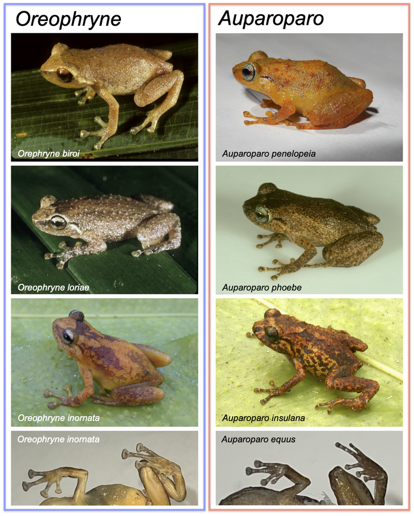

Figure 1: Photos of *Oreophryne* species on the left and *Auparoparo* species on the right. Both genera are aboreal with a few exceptions as noted in the text, and contain nearly all arboreal species within Asterophryinae. Comparison of finger and toe pad sizes in *Oreophryne inornata* BPBM16217 vs. *Auparoparo equus* BPBM15775, bottom row.

Large scale molecular phylogenetic analysis with many ingroup samples was required to reveal that this morphologically united group contains two reciprocally monophyletic clades that are not sister taxa (Hill *et al.*, 2022, 2023b). Early molecular phylogenetic studies suggested monophyly but only included a few species within a larger-scale study (Köhler & Günther, 2008 included 9 *Oreophryne* species; De Sa *et al.*, 2012 included 4). Rivera *et al.* (2017) provided the first molecular evidence of a polyphyletic *Oreophryne* with 36 *Oreophryne* species within a larger phylogeny Asterophryinae which included 155 samples, followed by Tu *et al.* (2018)’s sparse supermatrix approach with 18 species of *Oreophryne* falling out in various places within a much larger phylogeny, but both of these lacked strong nodal support connecting the hypothesized clades to the backbone of the phylogeny and were thus inconclusive. The polyphyletic nature of *Oreophryne* sensu lato was not clearly demonstrated until Hill et. al (2022, 2023b) included 44 species of *Oreophryne* (with data 96% complete for sampled loci) within a 218 taxon phylogeny of Asterophryinae. This phylogeny is the most complete and robust phylogeny to date. The two clades, labeled “*Oreophryne* A” and “*Oreophryne* B” have deep histories of ~ 18MY and ~16MY, respectively, with “*Oreophryne* A” sister to the rest of the subfamily (Hill *et al.*, 2022, 2023b).

# Materials and Methods

## Taxon Sampling

Asterophryinae is an adaptive radiation with short branch lengths along the backbone separating currently recognized genera (Rivera *et al.*, 2017; Hill *et al.*, 2022, 2023b); we reconstruct the phylogeny of *Oreophryne* sensu lato within the larger context of the subfamily. We include 30 named species and 18 unnamed species of *Oreophryne* within a larger dataset of 234 samples of 203 species of Asterophryinae collected across New Guinea, the Philippines, and Indonesia with three outgroup species to root the phylogeny (*Dyscophus antongilii*, *Scaphiophryne marmorata*, and *Platypelis grandis*). Importantly, we include the type species *Oreophryne senckenbergiana* (Boettger, 1895) in a molecular phylogeny for the first time. The samples were collected in Halmahera, North Maluku Province, Indonesia by Iqbal Setiadi , Table 1, between Supu and Dodinga, two type localities for *O. senkenbergiana* (Boettger, 1895), which was later synonymized with *O. moluccensis* (Parker, 1934).

Table 1: Locality information for samples sequenced in this study. See Hill, et al., 2023, Table 1 for additional metadata.

| ID | Species | Locality | LatLon | SIA | BDNF | NXC1 | CYTB | ND4 |
| --- | --- | --- | --- | --- | --- | --- | --- | --- |
| BJE01120 | Oreophryne moluccensis | Kabupaten Halmahera Utara, Halmahera Island, North Maluku | 1.8228, 127.8300 | PV703775 | PV703761 | PV703771 | PV703765 | PV703768 |
| BJE01143 | Oreophryne moluccensis | Kabupaten Halmahera Utara, Halmahera Island, North Maluku | 1.7899, 127.8910 | PV703776 | PV703762 | PV703772 | PV703766 | PV703769 |
| BJE01144 | Oreophryne moluccensis | Kabupaten Halmahera Utara, Halmahera Island, North Maluku | 1.7899, 127.8910 | PV703777 | PV703763 | PV703773 | PV703767 | PV703770 |

### Molecular Sequences

We obtained complete DNA sequence data for five loci (three nuclear: Seventh in Absentia [SIA], Brain Derived Neurotrophic Factor [BDNF], Sodium Calcium Exchange subunit-1 [NXC-1], and two mitochondrial loci (Cytochrome oxidase b [CYTB], and NADH dehydrogenase subunit 4 [ND4] from three samples of the type species (not previously sequenced) and combined these with previously published data (Rivera *et al.*, 2017; Hill *et al.*, 2022, 2023b) for a dataset of 240 samples with 207 species and 2475 base pairs that is 96% complete (loci complete for the added samples). Sequence quality was evaluated using chromatogram quality scores, checks for stop codons indicating pseudogenes, BLAST searches (Ye *et al.*, 2012), and concordance of pairwise similarities with other Asterophryinae sequences. Primer sequences and detailed methods including phylogenetic reconstruction are provided in (Hill *et al.*, 2023b). We note that we excluded from the previous alignment (Hill *et al.*, 2022, 2023b) two samples of *Aphantophryne pansa* (BPBM 5299 and BPBM 8312) which were deemed unreliable as they came from formalin-fixed material, and three samples which fell out in odd places that should be confirmed with new material prior to recommending taxonomic revision (BPBM 22708 *Copiula tyleri*, BPBM 38939 *Copiula sp. 7*, BPBM 37753 *Paedophryne dekot*). We note that genetic material from 47 species of *Oreophryne* sensu lato was not available for this molecular analysis.

### Morphology, Behavior, and Geographic Distribution

Table 2: Description of traits surveyed.

| Column* | Trait | Definition |
| --- | --- | --- |
| 1 | Procoracoids | Size and shape of the procoracoid cartilages, CR= curved, reduced |
| 2 | Clavicles | Size and shape of the clavicles, CR= curved, reduced |
| 3 | Omasternum | Presence (+) or absence (-) of the omasternum |
| 4 | Sternum | Cartilaginous sternum or sternal plate |
| 5 | Call type | Qualitative description of the call type |
| 6 | Finger:toe width | The ratio of finger pad width to toe pad width |
| 7 | Pectoral ligament | Cartilaginous or ligamentous connection between scapula and procoracoid |
| 8 | Rel toe length | Relative length of 5th toe compared to length of 3rd toe (5<3, 5=3, 5>3) |
| 9 | Toe webbing | Toe webbing assessed on 5th toe (absent (-), basally webbed, well webbed) |
| 10 | Tympanum:eye diameter | Tympanum diameter relative to eye diameter (¼, ⅓, or ½) |
|  | Pupil horizontal | Whether the pupil is horizontal |
|  | Teeth | Whether teeth are present |
|  | Palatal folds | Whether two horizontal palatal folds in front of the pharynx are present |

*Corresponding column in Table 3. The last three traits were scored and are invariable across species, thus not tabluated in Table 3.

## Nomenclature

We conducted a comprehensive taxonomic literature review of diagnoses for all species known to belong to the clades “*Oreophryne* A” and “*Oreophryne* B” (Hill *et al.*, 2022). We applied the ICZN code (International Commission on Zoological Nomenclature, 1999) as well as the Phylocode (De Queiroz, Kevin & Cantino, 2020). We support the nascent effort to assign indigenous names in taxonomy whenever possible (e.g., Gillman & Wright, 2020). One of us (B. Iova) proposed the novel genus name, *Auparoparo*, meaning “tree frog” in Motu, an indigenous language of Papua New Guinea, for “*Oreophryne* B”.

## Phylogenetic Reconstruction

We used Partitionfinder to find the best-fit evolutionary model followed by Maximum Likelihood (ML) phylogenetic reconstruction using IQTREE2 (Lanfear *et al.*, 2012; Minh *et al.*, 2020). Following Hill *et al.* (2022), we tested models partitioned by both locus and codon versus by loci only or by codon only (15 vs. 5 vs. 3 partition scheme) with merging of partitions allowed. We found following merging that a 9-partition scheme involving locus and codon models with merged partitions was superior by the Akaike Information Criterion (models by partition included in Supplementary Materials Table 1). Nodal support values for the ML tree were inferred using 1000 bootstrap replicates.

## Phylogenetic Definition

We use a maximum crown-clade definition under the PhyloCode (De Queiroz & Gauthier, 1990, 1992; De Queiroz, Kevin & Cantino, 2020), whereby monophyletic clades are defined by the largest crown clade containing their reference species (in the case of genus-level clades, the type species for the genus or a proxy when molecular phylogenetic data is not available for the type species). Specifically, the largest crown clade originating with the most recent common ancestor of the type species for the genus-level clade, and all extant species that share a more recent common ancestor with that type species then they do with reference species of other clades.

## Analyses, Visualization, and Data Availability

All analyses were conducted and graphics produced in the R Statistical Computing Environment (R Core Team, 2024) unless noted. Initial DNA sequence alignment was conducted using `MUSCLE` (Edgar, 2004) with manual adjustments in `Mesquite` (Maddison & Maddison, 2023). Phylogenetic reconstruction was conducted using the `IQTREE2` suite of software (Lanfear *et al.*, 2012; Minh *et al.*, 2020).

The known ranges of *Oreophryne* sensu lato were downloaded as shape files from the IUCN Red List database (IUCN, 2025), and plotted. Sites from collection locations for *Oreophryne* and *Auparoparo* were mapped using the `sf` and `ggplot2` packages (Wickham, 2016; Pebesma, 2018), overlaid on a basemap created using `rnaturalearth`, `grid`, and `ggspatial` packages (Dunnington, 2023; Massicotte & South, 2023). Tree graphics were produced with the `ggtree` package (Yu *et al.*, 2017; Yu, 2020) supplemented by `ggplot2` (Wickham, 2016).

# Results

## Phylogeny and Phylogenetic Taxonomy

For our subfamily-level phylogeny, the best evolutionary model was a 9 partition scheme including a combination of locus by codon partitions (see Supplementary Table 1 for list partitions and models). The best set of partitions and models had an improvement of fit by 223 AIC units over the 15-partition (locus by codon) model, 3750 AIC units better than the 5 partition locus-only model, and 4230 AIC units improvement over the 3 partition codon-only model. All phylogenetic reconstructions reported here used the best-fit model (9-partition scheme) identified by IQTREE2.

We recovered a maximum likelihood topology that confirms that *Oreophryne* sensu lato is polyphyletic, with species falling into two independently-evolved, reciprocally monophyletic, highly-supported clades that are not sister groups Figure 2. Nearly all nodes are moderately or highly supported, with most of the weakly supported nodes falling along the backbone where there are very short branch lengths as characteristic of an adaptive radiation.

Furthermore, these findings demonstrate that the crown clade descended from node A should retain the name *Oreophryne*, as the type species, *O. senckenbergiana*, from North Maluku Island, Indonesia, is situated within *Oreophryne* with high support (Figure 2). We propose the new clade name *Auparoparo* for the crown clade descended from node B. *Oreophryne* is the earliest diverging genus-level clade in the Papuan subfamily, with genera *Cophixalus* and *Paedophryne* arising before *Auparoparo*, which split from the remaining genera of Asterophryinae.

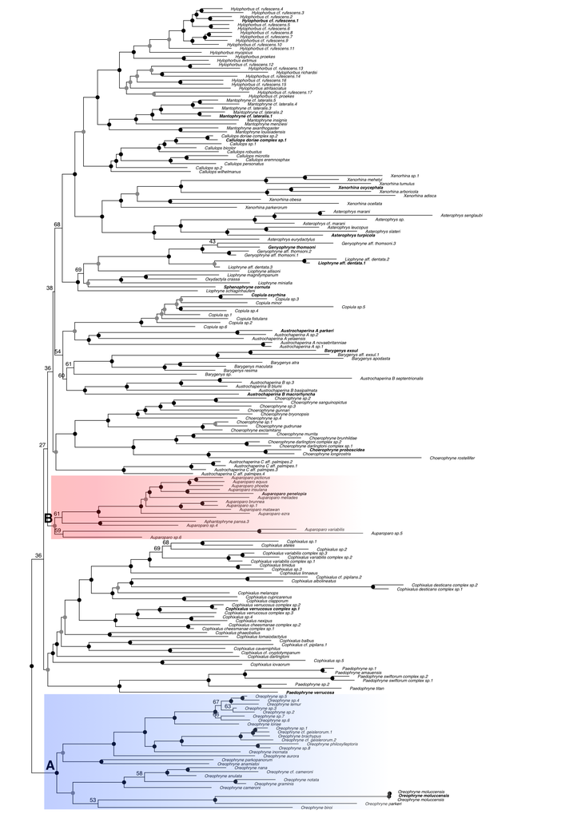

Figure 2: Molecular phyogenetic hypothesis of Asterophryinae showing polyphyly of *Oreophryne* sensu lato, into two reciprocally monophyletic clades that are not sister taxa. Node A is *Oreophryne* (blue clade) and node B is *Auparoparo* (red clade) based on the position of the type species *Oreophryne senkenbergiana*=*O. moluccensis*. Nodal support: black dots indicate ML boostrap support >= 95%, grey dots >= 75%, numeric values given for nodes below 75% support. Outgroup taxa excluded. Taxa in bold are the type species for each genus (or a proxy species used as an internal reference).

## Morphology, Behavior, and Ranked Taxonomy

We find no morphological synapomorphies that distinguish *Auparoparo* from *Oreophryne*. *Oreophryne* sensu lato is diagnosed by characters of the pectoral girdle: posessing highly reduced, curved procoracoid cartilages and clavicles, and lacking an omosternum (Parker, 1934; Zweifel, 2003). We found that this suite of characters is also present in *Auparoparo*, and therefore is not diagnostic for either *Oreophryne* or *Auparoparo* (Table 3).

Two traits imperfectly segregate between the clades, relative finger and toe pad widths and call type (Table 3), which may assist in tentative identification. Both *Oreophryne* and *Auparoparo* are arboreal clades with expanded digital pads. Species of *Oreophryne* have finger and toe pads generally of roughly equal width and most species of *Auparoparo* have visibly larger finger pads, with finger pads roughly 20-30% wider than toes. Both *Oreophryne* and *Auparoparo* use a variety of call types, with “honks” or “peeps” used only by *Oreophryne*, whereas “whinny” calls are used only by *Auparoparo*. A minority of species in both groups use the “rattle” call type. However, both toe pad width and call type are variable traits with some overlap and thus not unambiguosly diagnostic. Furthermore, possesssion of expanded digital pads is clearly an adaptive trait for arboreality and prone to homoplasy.

Table 3: Morphological character matrix.

| Genus | species | (1) proc | (2) clav | (3) omo | (4) ster | (5) call type | (6) fing: toe width | (7) pec lig | (8) rel toe len | (9) toe web | (10) tymp:eye diam | (11) character data reference |
| --- | --- | --- | --- | --- | --- | --- | --- | --- | --- | --- | --- | --- |
| Oreophryne | anamiatoi | CR | CR | – | cart | chuckle or cackle | 1.2 | cart | 5>3 | – | 1/4 | Kraus Allison 2009 |
|  | anulata1 | CR | CR | – | cart |  | slightly larger |  | 5>3 | – | 1/2 | Stejneger 1908 |
|  | aurora | CR | CR | – | cart | harsh croaks |  | lig | 5>3 | webbed | 1/4 | Kraus 2016 |
|  | biroi | CR | CR | – | cart | rattle | 1.1 | lig | 5=3 | webbed | 1/4 | Zweifel et al. 2003 |
|  | brachypus | CR | CR | – | cart | long squeak | 1.1 | lig | 5>3 | webbed | 1/4 | Zweifel et al. 2003 |
|  | cameroni | CR | CR | – | cart | peep |  | cart | 5>3 | basal | 1/4 | Kraus 2013 |
|  | frontifasciata1 | CR | CR | – | cart |  | slightly larger | cart | 5>3 | basal | 1/2 | Horst 1883, Brongersma 1948 |
|  | geislerorum | CR | CR | – | cart | rattle |  | lig | 5>3 | webbed | 1/3 | Zweifel et al. 2003 |
|  | graminis1 | CR | CR | – | cart | peep | approx equal | cart | 5>3 | – | 1/3 | Gunther Richards 2012 |
|  | inornata | CR | CR | – | cart | honk | 1.0 | lig | 5>3 | basal | 1/4 | Kraus 2016 |
|  | lemur | CR | CR | – | cart | honk |  | lig | 5>3 | basal | 1/4 | Kraus 2016 |
|  | loriae | CR | CR | – | cart | honk |  | lig | 5>3 | webbed | 1/3 | Kraus 2016 |
|  | moluccensis1 | CR | CR | – | cart |  | slightly larger |  | 5=3 | basal | 1/3 | Boettger 1895, Parker 1934 |
|  | nana1 | CR | CR | – | cart |  | approx equal | cart | 5<3 | – | 1/2 | Brown Alcala, 1967 |
|  | notata | CR | CR | – | cart | peep |  | cart | 5>3 | – | 1/4 | Zweifel 2003 |
|  | parkeri | CR | CR | – | cart | peep |  | lig | 5>3 | webbed | 1/3 | Kraus 2013, Zweifel et al. 2003 |
|  | parkopanorum | CR | CR | – | cart |  |  | cart | 5<3 | – | 1/4 | Kraus 2013 |
|  | philosylleptoris | CR | CR | – | cart | honk | 1.0 | lig | 5>3 | webbed | 1/3 | Kraus 2016 |
| Auparoparo2 | brunnea1 | CR | CR | – | cart | rattle | larger | lig | 5=3 | basal | 1/3 | Kraus 2017 |
|  | equus | CR | CR | – | cart | whinny | 1.3 | lig | 5=3 | basal | 1/4 | Kraus 2016 |
|  | ezra | CR | CR | – | cart | chatter |  | lig | 5>3 | basal | 1/4 | Kraus Allison 2009 |
|  | insulana | CR | CR | – | cart | whinny |  | lig | 5>3 | basal | 1/4 | Kraus 2016, Zweifel 1956 |
|  | matawan | CR | CR | – | cart | rattle |  | lig | 5≥3 | – | 1/4 | Kraus 2016 |
|  | meliades | CR | CR | – | cart | whinny | 1.2 | lig | 5=3 | basal | 1/3 | Kraus 2016 |
|  | penelopeia | CR | CR | – | cart | whinny | 1.3 | lig | 5>3 | basal | 1/4 | Kraus 2016 |
|  | phoebe | CR | CR | – | cart | whinny | 1.2 | cart | 5>3 | webbed | 1/4 | Kraus 2017 |
|  | picticrus | CR | CR | – | cart | whinny | 1.3 | lig | 5>3 | basal | 1/3 | Kraus 2016 |
|  | variabilis1 | CR | CR | – | cart |  | much larger | cart |  | – | >2/3 | Boulenger 1896 |

1Character states obtained from the literature, specimens not available for examination in this study.  
2Hill et al. 2022 places Aphantophryne pansa within Auparoparo, but the status of Aphantophryne requires further study with samples from additional species and localities.  
*External characters were examined from specimens, internal characters and pupil shape taken from the literature.

## Geographic Distribution

*Oreophryne* has a wide distribution with species spanning from the southern Philippines to the Papuan Louisade Archipelago (Figure 3, localities for *Oreophryne* species included in our phylogeny are mapped with blue triangles). This range encompasses the additional species from the type locality in Indonesia. *Auparoparo* is mainly clustered in the southeastern tip of mainland Papua New Guinea and its satellite islands with two species in Sulawesi, an Indonesian island (Figure 3, *Auparoparo* localities mapped in red circles). We also mapped *Oreophryne* sensu lato ranges obtained from the IUCN Red List (IUCN, 2025), which require phylogenetic diagnosis. Note the Indonesian region of New Guinea is difficult to attain samples from and it is unknown whether these groups inhabit this connective area.

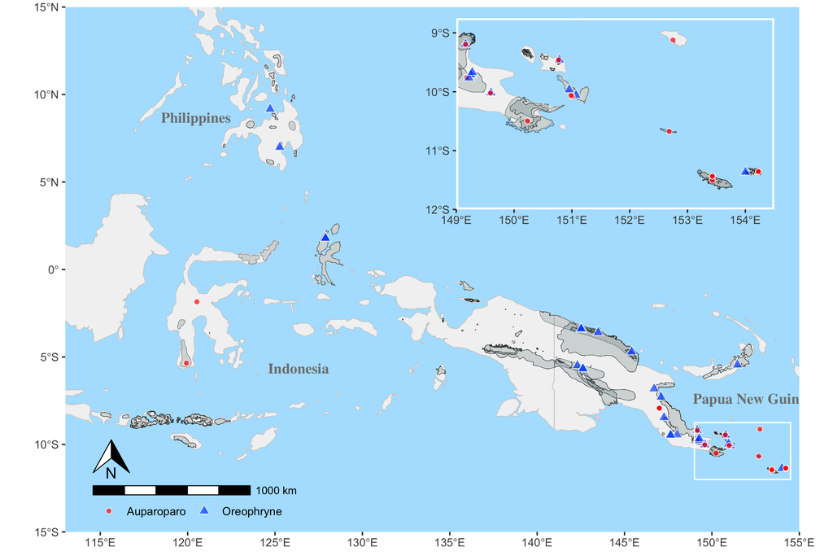

Figure 3: The known distribution of *Oreophryne* as currently recognized is plotted in grey polygons (data source IUCN, 2025), with points indicating *Auparoparo* (red) and *Oreophryne* (blue) as assigned by our phylogenetic analysis Figure 2. Note that there is range overlap along the East Papuan Composite Terrane and on some offshore islands (see inset).

## Taxonomy

We use maximum crown-clade definitions for designating *Oreophryne* and *Auparoparo* because the monophyly of these taxa are strongly supported, and the relationships of these taxa to each other and to other genera of Asterophryinae are well-supported (this study, Hill *et al.*, 2022, 2023b), as has been done for other anuran taxa (Brown *et al.*, 2015) following the methods of phylogenetic nomenclature (De Queiroz & Gauthier, 1990, 1992, 1994). That is, we adopt phylogenetic definitions of these genera that explicitly identify them as clades. Specifically, we define each genus to include all descendants of the most recent common ancestor of the type species and all other extant species that are more closely related to it than to the type species of the other Asterophryine genera recognized here. We retain the name *Oreophryne* for species included in the phylogenetic redefinition of *Oreophryne*, and new clade name *Auparoparo* for newly designated species of *Auparoparo*. The previously defined polyphyletic *Oreophryne* is indicated by “sensu lato”, which contains many species which require molecular phylogenetic assignment.

**Family Microhylidae Günther 1858**  
**Subfamily Asterophryinae Günther 1858**  
**Genus *Oreophryne* Boettger 1895 amended**  
*Microhyla* in part (Peters 1878)  
*Callula* in part (Horst 1883)  
*Oreophryne* Boettger 1895, by monotypy, Type species: *Oreophryne senckenbergiana* Boettger 1895. (= *Microhyla achatina* var. *moluccensis* Peters 1878) Placed on Official List of Generic Names in Zoology by Opinion 1266, Anonymous, 1984.  
*Sphenophryne* in part (Méhely 1897)  
*Phrynixalus* in part (Stejneger 1908)  
*Mehelyia* Wandolleck 1911, Type species: *Meheylia lineata* Wandolleck 1911 (= *Sphenophryne biroi* Mehely 1897), by subsequent designation of Parker 1934. Synonymy by Nieden (1926).  
*Cophixalus* in part (Boettger 1892)  
*Chaperina* in part (Taylor 1920)

**Diagnosis:** We note that there are no synapomorphies in adult *Oreophryne* that differ from the morphologically similar genus *Auparoparo*. Diagnoses should be made by molecular phylogenetic analysis, based on the phylogenetic definition below. *Oreophryne* differs from most other genera in subfamily Asterophryinae, but not from *Auparoparo*, by the combination of (1) presence of highly reduced clavicles (vs absence or elongate) which have a distinctly curved shape; (2) presence of well developed digital pads, often with finger and toe pads of similar size; (3) arboreal lifestyle (perch height >2m above ground); (4) most species range in body size from 16mm (*O. graminis*, Günther & Richards, 2012) to 30mm, with a few larger species ~40mm (*O. inornata*); (5) small to invisible tympanum; (6) large eyes with horizontal pupils; (7) occasional presence of toe webbing; (8) thin, elongated limbs; and (9) in many species males that call with “honk” or “peep” types or in some species “rattle” type. Some species of *Oreophryne* may be distinguished from *Auparoparo* by roughly equal finger to toe pad ratio and males calling with “honk” or “peep” but not “whinny” call types.

**Phylogenetic definition:** *Oreophryne* Boettger 1895 (Converted Clade Name) is defined as the largest crown clade including *Oreophryne senckenbergiana* Boettger 1895 and excluding the type species of the other genus-ranked clades listed in Table Table 4.

Table 4: Genus-level clades of Asterophryinae and their internal specifiers (type species or proxies).

| Genus-level clade | Internal Specifier (Type Species or proxy) |
| --- | --- |
| Asterophrys | Asterophrys turpicola (Schlegel 1837) |
| Auparoparo | Auparoparo penelopeia (Kraus 2016) |
| Austrochaperina* | Austrochaperina palmipes (Zweifel 1956) |
| Austrochaperina* | Austrochaperina robusta Fry 1912 |
| Barygenys | Barygenys cheesmanae Parker 1936 |
| Callulops | Callulops doriae Boulenger 1888 |
| Choerophryne | Choerophryne proboscidea Van Kampen 1914 |
| Cophixalus | Cophixalus verrucosus (Boulenger, 1898) |
| Copiula | Copiula oxyrhina (Boulenger 1898) |
| Genyophryne* | Genyophryne thomsoni Boulenger, 1890 |
| Hylophorbus | Hylophorbus rufescens Macleay 1878 |
| Mantophyrne | Mantophryne lateralis Boulenger 1897 |
| Liophryne* | Liophryne rhododactyla (Boulenger 1897) |
| Oreophryne | Oreophryne senckenbergiana Boettger 1895 (= O. moluccensis (Peters and Doria 1878)) |
| Oxydactyla | Oxydactyla brevicrus (Van Kampen 1913) |
| Paedophryne | Paedophryne kathismaphlox Kraus 2010 |
| Sphenophryne* | Sphenophryne cornuta Peters and Doria 1878 |
| Xenorhina | Xenorhina oxycephala (Schlegel 1858) |

*We note that the monophyly of Austrochaperina, Liophryne, Oxydactyla, and Sphenophryne (and reciprocal monophyly of Genyophryne [Genyophryne thomsoni Boulenger, 1890] with respect to Liophryne + Oxytactyla + Sphenophryne) has not yet been established. Austrochaperina is polyphyletic in recent phylogenies with possibly three monophyletic clades that are not sister taxa (Figure 2).

**Composition:** Our results support the retention of 17 species in *Oreophryne* with molecular evidence (Table 5): *Oreophryne anamiatoi* Kraus 2009, *O. anulata* (Stejneger 1908), *O. aurora* Kraus 2016, *O. biroi* Mehely 1897, *O. brachypus* Werner 1898, *O. cameroni* Kraus 2013, *O. geislerorum* Boettger 1892, *O. graminis* Gunther 2012, *O. inornata* Zweifel 1956, *O. lemur* Kraus 2016, *O. loriae* Boulenger 1898, *O. nana* Brown 1967, *O. notata* Zweifel 2003, *O. parkeri* Loveridge 1955, *O. parkopanorum* Kraus 2013, *O. philosylleptoris* Kraus 2016, and *O. moluccensis* (Peters 1878). A number of species were not available for our study but should molecular evidence demonstrate their relationship within *Oreophryne*, those species should also retain their generic identity.

**Distribution:** The range of confirmed *Oreophryne* species in this dataset remains nearly as broad as previously defined (Figure 3), from the Philippines and Indonesia to the southeastern most tip of mainland New Guinea and several near-shore islands (Fergusson, and Normanby Is.) and the distant Rossel Island of the Louisiade Archipelago. However, the transfer of species which occupy Woodlark Islands and Misima and Sudest Islands of the Louisaide Archipelago reduces the known range of *Oreophryne*. Woodlark Island is inhabited by *O. phoebe* [=*Auparoparo phoebe*], Misima Island is inhabited by *O. picticrus* [=*Auparoparo picticrus*], and Sudest Island is inhabited by *O. ezra* and *O. meliades* [= *Auparoparo ezra* and *Auparoparo meliades*].

**Genus *Auparoparo* gen. nov.**  
*Oreophryne* in part (Boettger, 1895)  
*Sphenophryne* in part (Boulenger, 1897)  
Type species *Oreophryne penelopeia* (Kraus, 2016) [=*Auparoparo penelopeia*]

**Diagnosis:** Currently, there are no known synapomorphies in adult *Auparoparo* that differ from the morphologically similar genus *Oreophryne*. Diagnoses should be made by molecular phylogenetic analysis, based on the phylogenetic definition below. *Auparoparo* differs from most other genera in subfamily Asterophryinae, but not from *Oreophryne*, by the combination of (1) presence of highly reduced clavicles (vs absence or elongate) which have a distinctly curved shape; (2) presence of well developed digital discs, with finger discs notably wider than toe discs (typically 20% or more); (3) arboreal lifestyle (perch height >2m above ground); (4) small to moderately large body size in known species, from 16mm (*A. brunnea* Kraus 2017) to 25 mm (*A. picticrus* Kraus 2016); (5) small to invisible tympanum; (6) large eyes with horizontal pupils; (7) occasional presence of toe webbing; (8) and thin, elongated limbs; and (9) and in many species males that call with a “whinny” call type or in some species “rattle” type. Some species of *Auparoparo* may be distinguished from *Oreophryne* by larger finger pads than toe pads and males calling with “whinny” but not “honk” or “peep” call types.

**Phylogenetic definition:** *Auparoparo* (New Clade Name) applies to the largest crown clade including *Auparoparo penelopia* (Kraus 2016) and excluding the type species of the other genus-ranked clades listed in Table 4.

**Distribution:** Southeastern tip of mainland Papua New Guinea and satellite islands (Fergusson, Misima, Normanby, Rossel, Sudest, Woodlark Is.), Sulawesi.

**Etymology:** The generic name *Auparoparo* comes from the indigenous language, Motu, which is widely spoken in the region of Papua New Guinea in which this genus is found. It is a combination of the words “au” (tree) and “paro paro” (frog). Motu is not a gendered language, however, for nomenclatural purposes we designate the genus *Auparoparo* as feminine, thereby preserving the gender of existing species names.

# Discussion

Our phylogenetic results (Hill *et al.*, 2022; 2023b, this study) provide clarity on the classification of the problematic genus *Oreophryne* as currently recognized. We confirm that *Oreophryne* sensu lato is polyphyletic and consists of two reciprocally monophyletic clades that are not sister taxa (Figure 2). Here we designate “*Oreophryne* A” in Hill *et al.* (2022) as the genus *Oreophryne* because it contains the type species *Oreophryne senckenbergiana* Boettger 1895 with high support. *Oreophryne* is the earliest diverged genus in subfamily Asterophryinae originating approximately 18 MYA (Hill *et al.*, 2022), and is sister to a clade composed of all the other genera. The second clade, “*Oreophryne* B” in Hill *et al.* (2022), is highly supported as a separate, non-sister genus, which originated approximately 16 MYA and contains no known species that are the types of any previously proposed genera. Thus, we designate this genus as *Auparoparo*, a tribute to the Motu language of the indigenous peoples of the region.

## The Difficulty with Cryptic Genera: Can we tell them apart?

Perhaps the greatest testament to the crypticism of *Oreophryne* vs. *Auparoparo* is that no taxonomist was able to distinguish that they are separate clades, independently evolved, in the 130 years between their discovery and the present classification [Boettger (1895); this study]. These species are indeed morphologically very similar (Figure 1) and our results provide some clues as to why *Oreophryne* taxonomy has been so difficult. We found morphological synapomorphies for neither *Auparoparo* nor *Oreophryne*, and moreover, no morphological features that can diagnose either clade.

The traditional basis for assigning species to *Oreophryne* has primarily relied on a signature pectoral anatomy (whether original or revised diagnosis, Parker, 1934; Zweifel, 2003). Our phylogenetic results clearly show that this trait appears more than once, in both *Oreophryne* and *Auparaparo*, is either a symplesiomorphy (shared ancestral character) or a result of convergent or parallel evolution, and perhaps adaptive for arboreality. Thus, the pectoral anatomy is not a reliable diagnostic character in differentiating between *Oreophryne* and *Auparoparo*. In studies across a wide diversity of anurans, Soliz *et al.* (2025) found that anatomical variation of the pectoral girdle corresponds with functional and ecological lifestyle demands, whereas Engelkes *et al.* (2020) found strong phylogenetic influence in the shape of the pectoral girdle. The pectoral girdle would be excellent for further study within Asterophryinae, as there are high elevation terrestrial species of *Oreophryne* sensu lato that possess the same pectoral trait (Zweifel *et al.*, 2005), as well as a few arboreal species within other genera (*Cophixalus*, *Asterophrys*, *Xenorhina*) with unstudied pectoral morphology.

We further rexamined additional characters previously used to diagnose *Oreophryne* as well as characters conventionally used to diagnose species of frogs. We conclude that pectoral girdle connector type (Parker, 1934) and relative lengths of the 3rd and 5th toe are uninformative and the degree of toe webbing is variable. It was previously suggested that species in *Oreophryne* sensu lato could be divided into two groups based on possessing a cartilaginous or ligamentous connection between the procoracoid cartilages and the scapula (Kraus, 2013), with roughly half possessing each type (Parker, 1934). However, we found that cartilaginous and ligamentous connectors are common across both genera (Table 3); therefore, these traits are not synapmorphies for *Oreophryne* or *Auparoparo* and do not indicate monophyly for these clades. Of species with toe webbing, *Oreophryne* tends to be described as having “well webbed” toes compared to *Auparoparo*’s “basal” webbing (Table 3). However, the presence of intra-specific variability combined with subjectivity in judging relative landmarks (e.g., “reaching the penultimate tubercle”, “webbed 1/3 length of 5th toe”, etc.), makes this feature difficult to standardize for generic diagnostic use. Many of the morphological traits proposed by Parker (1934) and Zweifel (2003) may in fact be a result of homoplasy via convergent lifestyle or parallel evolution, and while they may prove useful for ecomorphological identification or species diagnoses in combination with other traits, they are not informative for generic diagnosis.

We found only two characters with potential for imperfectly distinguishing the genera: relative digital pad size (Parker, 1934; Zweifel, 1956), and call type (e.g., Kraus, 2016). The relative widths of the digit pads differs between genera: *Auparoparo* tends to have visibly larger finger pads in comparison to toe pads, whereas in *Oreophryne* the finger and toe pads are roughly equal in size (Figure 1, bottom row), although there is some overlap in finger to toe pad ratio (Table 3). In some cases, *Auparoparo*’s finger pads display T-shapes while the toes are often rounder and narrower. Whether there is any performance advantage in larger finger pads compared to toes is unknown. Furthermore, a handful of high-elevation *Oreophryne* species not included in our phylogeny and yet to be diagnosed by molecular phylogenetic analysis have evolved terrestrial or fossorial habits and possess smaller digital pads compared to their presumed arboreal relatives (Zweifel *et al.*, 2005).

Call features are increasingly used for diagnosing species of *Oreophryne*, with advertisement call types commonly categorized as rattle, honk, whinny, peeping, or clicking (Kraus, 2016). We found honk or peep call types are only found in *Oroephryne* species in our sample, while whinny calls are only found in *Auparoparo* species, and rattle calls are found in both genera (Table 3). We note that several authors described species of both genera, thus the difference between genera cannot be attributed to the investigator. However, more complete sampling may add further complexity. As far as we are aware there has been no comprehensive acoustic analysis across *Oreophryne* sensu lato. More research is needed to explore call diversity both between species and across genera to understand call evolution and whether there any features that are distinctive of genera.

## Geographic Distribution

The known distribution of *Auparoparo* is mainly clustered in the southeastern tip of mainland Papua New Guinea (in the East Papuan Composite Terrane) and satellite islands with two species in Sulawesi, Indonesia. This suggests the possiblity of of interesting plate tectonics resulting in this biogeographic distribution. Exploration of intermediate localities may result in as yet undescribed or undiscovered species of *Auparoparo*. The geographic range is sure to grow with additional phylogenetic sampling. For example *Oreophryne* (sensu lato) *chlorops* (Günther *et al.*, 2023) is a very large (SVL > 40mm) species recently discovered from mid-elevation mountains of the birdʻs neck region of Western Papua with clearly enlarged finger pads relative to toe pads. If confirmed as *Auparoparo*, it would significantly expand the range of *Auparoparo* across New Guinea Island.

We found geographic range overlap between *Oreophryne* and *Auparoparo* at multiple localities: on the mainland along the Mt. Dayman Foothills, at the Mt. Simpson Massif, Mt. Trafalgar, and on the oceanic islands of Normanby and Fergusson (both nearshore islands), and Rossel island (hundreds of kilometers offshore), which presents interesting questions regarding biogeography as well as their ecological relationships. For example, *Oreophryne inornata* and *Auparoparo insulana* have been collected at the same site (Goodenough Island) and even the same microhabitats (Zweifel, 1956). Do these species occupy the same niche, and what is the temporal history of each colonization? Are both genera also present in the nearby islands of Normanby and Fergusson (all part of the D’Entrecasteaux Archipelago)? Obtaining additional geographical samples for inclusion in phylogenetic analysis should be a high priority to gain a more complete understanding of the geographic distribution and evolutionary history of both *Oreophryne* and *Auparoparo*.

## How to Avoid a Misleading Classification

We adopt an explicitly phylogenetic framework for the new taxonomy of the genera *Oreophryne* and *Auparoparo*, and to our knowledge, this is the first time that phylogenetic nomenclature has been applied within the subfamily Asterophryinae. A phylogenetic definition of genera is advantageous especially because Asterophryinae is an adaptive radiation. While we are increasingly confident that at least 16 genera are indeed monophyletic, nevertheless, very short branch lengths separate many of the genera along the backbone [Hill *et al.* (2022); this study]. A maximum-crown-clade definition with multiple external specifiers is robust to uncertainty (i.e., rearrangements of order) along the backbone. We define each genus as the largest crown clade including the internal specifier species for the clade (i.e., the type species of the genus) but not the internal specifier species of other asterophryine genera. For long-studied groups such as Asterophryinae, it may not be possible to obtain a genetic sample for type species that were collected in the 1800ʻs and early 1900ʻs, as these locations may be uncertain and/or remote, it may be necessary to use a genetic sample from another species of the genus as a proxy for the type species. Nevertheless, is increasingly clear that for *Oreophryne* and *Auparoparo*, a molecular phylogenetic approach is required for final confirmation of taxonomy.

Furthermore, a phylogenetic definition provides guidance for robust classification. It is imperative that when assiging new species to either *Oreophryne* or *Auparoparo*, molecular confirmation requires – at minimum – inclusion of members of the other clade to correctly identify the genus level clade. For example, a phylogenetic analysis with only *Oreophryne* sensu lato and outgroups to Asterophryinae will show incorrect grouping of *Oreophryne* and *Auparoparo* species because of the lack of intervening species assigned to other Asterophryinae genera. An additional difficulty here is that each clade, *Oreophryne* and *Auparoparo*, contains subclades with deep histories (Hill *et al.*, 2023a), so we recommend the inclusion of additional intervening species assigned to other Asterophryinae genera, particularly *Cophixalus* and *Paedophryne*, to reduce the potential for long-branch attraction and more clearly resolve the “boundaries” of each monophyletic clade.

This study furthermore highlights the importance of taxonomic sampling for robust phylogenetic results. Developing an orderly taxonomy in a clade with over 350 named species (with a sizeable proportion of specimens in museum collections that are yet to be described, A. Allison, unpublished) would be that much more challenging without the benefit of generic diagnoses that follow evolutionary history.

## Conclusion: Why the Names Matter

Clarifying the generic structure also facilitates appreciation for the patterns of diversification within Asterophryinae. The evolutionary history of this subfamily is characterized by several interesting trends across genera: 1) a burst of ecological and species diversification leading to generic-level clades occurring early in the history of the subfamily (Hill *et al.*, 2022), 2) a tendency toward niche conservatism within genera, and 3) simultaneous dispersal of multiple genera to offshore islands (Hill *et al.*, 2022, 2023a) revealing the very strong influence of plate tectonics for explaining the historical dispersal patterns of this group. Finally, without distinct generic names for the two clades represented by *Oreophyne* and *Auparoparo*, it becomes much more difficult to appreciate independently evolutionary histories embodied by each clade, that aboreality has evolved at least twice in two large clades of Asterophyrinae, and would make it very difficult to appreciate the impressive paralleism embodied by these speciose and successful genera. An accurate and informative taxonomy serves to advance our understanding of Papuan microhylids and their very interesting evolutionary history leading to further discovery.

Lastly, we emphasize that future naming of species, genera, and higher taxa should seek to recognize the language of the indigenous stewards of the land and ecosystem from which they were discovered (Gillman & Wright, 2020). This is especially true of Asterophryinae frogs, whose awe-inspiring diversity mirrors the rich cultural beauty and historical complexity of Papuan people.

# Acknowledgements

We thank Ben Evans and Iqbal Setiadi for generously providing samples critical for this study, and Ethan Hill for his guidance and training on the molecular and bioinformatics work. We are grateful to Molly Hagemann and Samantha Shizuru for their excellent assistance in accessing Bishop Museum Vertebrate Zoology Collections and data. We thank Kevin de Queiroz for sharing expert knowledge on phylogenetic and zoological nomenclature, and Neal Evenhuis for sharing expert knowledge on type species. We thank Kevin de Queiroz, Brianna Correa, and Alexis Shulga for provided comments which greatly improved the manuscript. This is publication 234 from the School of Life Sciences, University of Hawaiʻi at Mānoa and 2026-004 from the Pacific Biological Survey, Bishop Museum.

# CRediT Statement

**Allison R. Fisher** (Conceptualization, Methodology, Data Collecting, Analysis, Writing, Reviewing, and Editing), **Ke Cao** (Data Collecting, Analysis, Writing, Editing), **Allen Allison** (Conceptualization, Writing, Reviewing, and Editing), **Bulisa Iova** (Collections, Land Access, Writing), and **Marguerite A. Butler** (Conceptualization, Analysis, Visualization, Supervision, Writing, Editing)

# Supplementary Data

Table 5: Classification of *Auparoparo* and *Oreophryne* based on phylogenetic evidence from two mitochondrial gene fragments (CytB, ND4) and three nuclear loci (BDNF, SIA, NXC). Incertae sedis taxa require phylogenetic evidence for classification.

| Original designation | Citation | Previous generic placement | Current generic placement | Species | Notes |
| --- | --- | --- | --- | --- | --- |
| Oreophryne anamiatoi | Kraus & Allison, 2009 | Oreophryne | Oreophryne | anamiatoi | Retained in Oreophryne |
| Phrynixalus anulatus | Stejneger, 1908 | Oreophryne | Oreophryne | anulata | Retained in Oreophryne |
| Oreophryne aurora | Kraus, 2016 | Oreophryne | Oreophryne | aurora | Retained in Oreophryne |
| Sphenophryne biroi | Méhely, 1897 | Oreophryne | Oreophryne | biroi | Retained in Oreophryne |
| Hylella brachypus | Werner, 1898 | Oreophryne | Oreophryne | brachypus | Retained in Oreophryne |
| Oreophryne cameroni | Kraus, 2013 | Oreophryne | Oreophryne | cameroni | Retained in Oreophryne |
| Cophixalus geislerorum | Boettger, 1892 | Oreophryne | Oreophryne | geislerorum | Retained in Oreophryne |
| Oreophryne graminis | Günther & Richards, 2012 | Oreophryne | Oreophryne | graminis | Retained in Oreophryne |
| Oreophryne inornata | Zweifel, 1956 | Oreophryne | Oreophryne | inornata | Retained in Oreophryne |
| Oreophryne lemur | Kraus, 2016 | Oreophryne | Oreophryne | lemur | Retained in Oreophryne |
| Sphenophryne loriae | Boulenger, 1898 | Oreophryne | Oreophryne | loriae | Retained in Oreophryne |
| Microhyla achatina | var. moluccensis Peters and Doria, 1878 | Oreophryne | Oreophryne | moluccensis | Retained in Oreophryne |
| Oreophryne nana | Brown & Alcala, 1967 | Oreophryne | Oreophryne | nana | Retained in Oreophryne |
| Oreophryne notata | Zweifel, 2003 | Oreophryne | Oreophryne | notata | Retained in Oreophryne |
| Oreophryne parkeri | Loveridge, 1955 | Oreophryne | Oreophryne | parkeri | Retained in Oreophryne |
| Oreophryne parkopanorum | Kraus, 2013 | Oreophryne | Oreophryne | parkopanorum | Retained in Oreophryne |
| Oreophryne philosylleptoris | Kraus, 2016 | Oreophryne | Oreophryne | philosylleptoris | Retained in Oreophryne |
| Oreophryne brunnea | Kraus, 2017 | Oreophryne | Auparoparo | brunnea | Transferred to Auparoparo |
| Oreophryne equus | Kraus, 2016 | Oreophryne | Auparoparo | equus | Transferred to Auparoparo |
| Oreophryne ezra | Kraus & Allison, 2009 | Oreophryne | Auparoparo | ezra | Transferred to Auparoparo |
| Oreophryne gagneorum | Kraus, 2013 | Oreophryne | Auparoparo | gagneorum | Transferred to Auparoparo |
| Oreophryne insulana | Zweifel, 1956 | Oreophryne | Auparoparo | insulana | Transferred to Auparoparo |
| Oreophryne matawan | Kraus, 2016 | Oreophryne | Auparoparo | matawan | Transferred to Auparoparo |
| Oreophryne meliades | Kraus, 2016 | Oreophryne | Auparoparo | meliades | Transferred to Auparoparo |
| Oreophryne penelopeia | Kraus, 2016 | Oreophryne | Auparoparo | penelopeia | Transferred to Auparoparo |
| Oreophryne phoebe | Kraus, 2017 | Oreophryne | Auparoparo | phoebe | Transferred to Auparoparo |
| Oreophryne picticrus | Kraus, 2016 | Oreophryne | Auparoparo | picticrus | Transferred to Auparoparo |
| Sphenophryne variabilis | Boulenger, 1896 | Oreophryne | Auparoparo | variabilis | Transferred to Auparoparo |
| Oreophryne albitympanum | Günther, Richards, and Tjaturadi, 2018 | Oreophryne | incertae sedis | albitympanum |  |
| Oreophryne albomaculata | Günther, Richards, and Dahl, 2014 | Oreophryne | incertae sedis | albomaculata |  |
| Sphenophryne albopunctata | Van Kampen, 1909 | Oreophryne | incertae sedis | albopunctata |  |
| Oreophryne alticola | Zweifel, Cogger, and Richards, 2005 | Oreophryne | incertae sedis | alticola |  |
| Oreophryne ampelos | Kraus, 2011 | Oreophryne | incertae sedis | ampelos |  |
| Oreophryne anser | Kraus, 2016 | Oreophryne | incertae sedis | anser |  |
| Sphenophryne anthonyi | Boulenger, 1897 | Oreophryne | incertae sedis | anthonyi |  |
| Oreophryne asplenicola | Günther, 2003 | Oreophryne | incertae sedis | asplenicola |  |
| Oreophryne atrigularis | Günther, Richards, and Iskandar, 2001 | Oreophryne | incertae sedis | atrigularis |  |
| Oreophryne banshee | Kraus, 2016 | Oreophryne | incertae sedis | banshee |  |
| Oreophryne brevicrus | Zweifel, 1956 | Oreophryne | incertae sedis | brevicrus |  |
| Oreophryne brevirostris | Zweifel, Cogger, and Richards, 2005 | Oreophryne | incertae sedis | brevirostris |  |
| Sphenophryne celebensis | Müller, 1894 | Oreophryne | incertae sedis | celebensis |  |
| Oreophryne choerophrynoides | Günther, 2015 | Oreophryne | incertae sedis | choerophrynoides |  |
| Oreophryne chlorops | Günther, Iskandar, and Richards, 2023 | Oreophryne | incertae sedis | chlorops |  |
| Oreophryne clamata | Günther, 2003 | Oreophryne | incertae sedis | clamata |  |
| Cophixalus crucifer | Van Kampen, 1913 | Oreophryne | incertae sedis | crucifer |  |
| Oreophryne curator | Günther, Richards, and Dahl, 2014 | Oreophryne | incertae sedis | curator |  |
| Oreophryne flava | Parker, 1934 | Oreophryne | incertae sedis | flava |  |
| Oreophryne flavomaculata | Günther and Richards, 2016 | Oreophryne | incertae sedis | flavomaculata |  |
| Callula frontifasciata | Horst, 1883 | Oreophryne | incertae sedis | frontifasciata |  |
| Oreophryne furu | Günther, Richards, Tjaturadi, and Iskandar, 2009 | Oreophryne | incertae sedis | furu |  |
| Oreophryne geminus | Zweifel, Cogger, and Richards, 2005 | Oreophryne | incertae sedis | geminus |  |
| Oreophryne habbemensis | Zweifel, Cogger, and Richards, 2005 | Oreophryne | incertae sedis | habbemensis |  |
| Oreophryne hypsiops | Zweifel, Menzies, and Price, 2003 | Oreophryne | incertae sedis | hypsiops |  |
| Oreophryne idenburgensis | Zweifel, 1956 | Oreophryne | incertae sedis | idenburgensis |  |
| Oreophryne jeffersoniana | Dunn, 1928 | Oreophryne | incertae sedis | jeffersoniana |  |
| Oreophryne kampeni | Parker, 1934 | Oreophryne | incertae sedis | kampeni |  |
| Oreophryne kapisa | Günther, 2003 | Oreophryne | incertae sedis | kapisa |  |
| Sphenophryne mertoni | Roux, 1910 | Oreophryne | incertae sedis | mertoni |  |
| Oreophryne minuta | Richards and Iskandar, 2000 | Oreophryne | incertae sedis | minuta |  |
| Sphenophryne monticola | Boulenger, 1897 | Oreophryne | incertae sedis | monticola |  |
| Oreophryne nicolasi | Richards and Günther, 2019 | Oreophryne | incertae sedis | nicolasi |  |
| Oreophryne oviprotector | Günther, Richards, Bickford, and Johnston, 2012 | Oreophryne | incertae sedis | oviprotector |  |
| Oreophryne pseudasplenicola | Günther, 2003 | Oreophryne | incertae sedis | pseudasplenicola |  |
| Oreophryne pseudunicolor | Günther and Richards, 2016 | Oreophryne | incertae sedis | pseudunicolor |  |
| Oreophryne purari | Günther, Nagombi, and Richards, 2025 | Oreophryne | incertae sedis | purari |  |
| Oreophryne roedeli | Günther, 2015 | Oreophryne | incertae sedis | roedeli |  |
| Oreophryne rookmaakeri | Mertens, 1927 | Oreophryne | incertae sedis | rookmaakeri |  |
| Oreophryne riyantoi | Putri, Trilaksono, Kurniati, Engilis, and Hamidy, 2023 | Oreophryne | incertae sedis | riyantoi |  |
| Oreophryne sibilans | Günther, 2003 | Oreophryne | incertae sedis | sibilans |  |
| Oreophryne streiffeleri | Günther and Richards, 2012 | Oreophryne | incertae sedis | streiffeleri |  |
| Oreophryne terrestris | Zweifel, Cogger, and Richards, 2005 | Oreophryne | incertae sedis | terrestris |  |
| Oreophryne unicolor | Günther, 2003 | Oreophryne | incertae sedis | unicolor |  |
| Oreophryne waira | Günther, 2003 | Oreophryne | incertae sedis | waira |  |
| Oreophryne wapoga | Günther, Richards, and Iskandar, 2001 | Oreophryne | incertae sedis | wapoga |  |
| Hylella wolterstorffi | Werner, 1901 | Oreophryne | incertae sedis | wolterstorffi |  |
| Oreophryne zimmeri | Ahl, 1933 | Oreophryne | incertae sedis | zimmeri |  |

# Conflict of Interest

The authors declare no conflict of interest.

# Funding

This study was made possible by a grant from the National Science Foundation awarded to M.A.B. (DEB-1145733). Many of the specimens examined were collected under grants awareded to A.A. (DEB-0103794, DEB-0445213, DEB-4001715). We gratefully acknowledge support from the School of Life Sciences and the Chancellorʻs Office, University of Hawai’i at Mānoa. University of Hawaii Information Technology Services – Cyberinfrastructure resources were funded in part by a National Science Foundation Major Research Instrumentation award (CNS-1920304).

# Data Availability Statement

The data underlying this article are available in the GenBank Nucleotide Database [accession numbers PV703761-PV703777] at https://www.ncbi.nlm.nih.gov/genbank/. The codes and datafiles needed to reproduce these results can be found at [GitHub repository] with DOI [supplied upon publication].

## References

**Ahl E**. **1933**. Ergebnisse der Celebes-und Halmaheira-Expedition Heinrich 1930–32. *Mitteilungen aus dem Zoologischen Museum in Berlin* **19**: 577–583.

**Alcala AC**. **1986**. *[Guide to Philippine Flora and Fauna: Amphibians and Reptiles](https://books.google.com/books?id=QKMtAAAAMAAJ)* (Natural Resources Management Center (Philippines), Ed.). Natural Resources Management Center, Ministry of Natural Resources; University of the Philippines.

**Balinton RB** & **de la Seña CA**. **2015**. [Karyotype of a rare minute frog, *Oreophryne* cf. anulata (Anura: Microhylidae), in Agusan Marsh, Mindanao, Philippines](https://api.semanticscholar.org/CorpusID:202544117). *The Herpetological Bulletin*.

**Boettger O**. **1895**. Liste der Reptilien und Batrachier der Insel Halmaheira nach den Sammlungen Prof. Dr. W. Kükenthal’s. *Zoologischer Anzeiger* **18**: 129–138.

**Boulenger GA**. **1888**. Descriptions of new reptiles and batrachians obtained by Mr. H. O. Forbes in New Guinea. *Annals and Magazine of Natural History, Series 6,* **1**: 343–346.

**Boulenger GA**. **1890**. Second report on additions to the batrachian collection in the Natural-History Museum. *Proceedings of the Zoological Society of London*: 323–328.

**Boulenger GA**. **1896**. [Descriptions of new reptiles and batrachians obtained by Mr. Alfred Everett in Celebes and Jampea](https://www.biodiversitylibrary.org/item/53362). *The Annals and magazine of natural history; zoology, botany, and geology, Series 6* **18**: 62–64.

**Boulenger GA**. **1897**. Descriptions of new lizards and frogs from Mount Victoria, Owen Stanley Range, New Guinea, collected by Mr. A. S. Anthony. *Annals and Magazine of Natural History, Series 6* **19**: 6–13.

**Boulenger GA**. **1898B**. Fourth report on additions to the batrachian collection in the Natural-History Museum. *Proceedings of the Zoological Society of London*: 473–482.

**Boulenger GA**. **1898A**. An account of the reptiles and batrachians collected by Dr. L. Loria in British New Guinea. *Annali del Museo civico di storia naturale di Genova, Serie 2* **18**: 695–710.

**Brown RM**, **Siler CD**, **Richards SJ**, **Diesmos AC** & **Cannatella DC**. **2015**. [Multilocus phylogeny and a new classification for Southeast Asian and Melanesian forest frogs (family Ceratobatrachidae)](https://doi.org/10.1111/zoj.12232). *Zoological Journal of the Linnean Society* **174**: 130–168.

**De Queiroz, Kevin** & **Cantino P**. **2020**. *[International Code of Phylogenetic Nomenclature (PhyloCode)](https://doi.org/10.1201/9780429446320)*. CRC Press.

**De Queiroz K** & **Gauthier J**. **1990**. [Phylogeny as a central principle in taxonomy - phylogenetic definitions of taxon names](https://doi.org/10.2307/2992353). *Systematic Zoology* **39**: 307–322.

**De Queiroz K** & **Gauthier J**. **1992**. [Phylogenetic taxonomy](https://doi.org/10.1146/annurev.ecolsys.23.1.449). *Annual Review of Ecology, Evolution, and Systematics* **23**: 449–480.

**De Queiroz K** & **Gauthier J**. **1994**. Toward a phylogenetic system of biological nomenclature. *Trends in Ecology & Evolution* **9**: 27–31.

**De Sa RO**, **Streicher JW**, **Sekonyela R**, **Forlani MC**, **Loader SP**, **Greenbaum E**, **Richards S** & **Haddad CFB**. **2012**. [Molecular phylogeny of microhylid frogs (Anura: Microhylidae) with emphasis on relationships among New World genera](https://doi.org/{10.1186/1471-2148-12-241}). *BMC Evolutionary Biology* **12**.

**Dunnington D**. **2023**. *[ggspatial: Spatial Data Framework for ggplot2](https://CRAN.R-project.org/package=ggspatial)*.

**Edgar RC**. **2004**. [Muscle: a multiple sequence alignment method with reduced time and space complexity](https://doi.org/10.1186/1471-2105-5-113). *BMC Bioinformatics* **5**: 113.

**Engelkes K**, **Kath L**, **Kleinteich T**, **Hammel JU**, **Beerlink A** & **Haas A**. **2020**. [Ecomorphology of the pectoral girdle in anurans (Amphibia, Anura): Shape diversity and biomechanical considerations](https://doi.org/10.1002/ece3.6784). *ECOLOGY AND EVOLUTION* **10**: 11467–11487.

**Frost DR**. **2024**. [Amphibian Species of the World: an Online Reference. Version 6.2](https://doi.org/doi.org/10.5531/db.vz.0001). *American Museum of Natural History, New York, USA.*

**Fry DB**. **1912**. Description of austrochaperina, a new genus of engystomatidae from north australia. *Records of the Australian Museum* **9**: 87–106.

**Gillman LN** & **Wright SD**. **2020**. [Restoring indigenous names in taxonomy](https://doi.org/10.1038/s42003-020-01344-y). *Communications Biology* **3**: 609.

**Günther ACLG**. **1858**. On the systematic arrangement of the tailless batrachians and the structure of *Rhinophrynus dorsalis*. *Proceedings of the Zoological Society of London*: 339–352.

**Günther R**, **Iskandar DT** & **Richards SJ**. **2023**. [A new large *Oreophryne* species from the mountains of Papua Province, Indonesian New Guinea (Amphibia, Anura, Microhylidae)](https://doi.org/10.3897/vz.73.e94207). *Vertebrate Zoology* **73**: 153–159.

**Günther R** & **Richards SJ**. **2012**. Five new microhylid frog species from Enga Province, Papua New Guinea, and remarks on *Albericus alpestris* (Anura, Microhylidae). *VERTEBRATE ZOOLOGY* **61**: 343–372.

**Günther R**, **Richards S** & **Iskandar DT**. **2001**. Two new species of the genus *Oreophryne* from Irian Jaya, Indonesia (Amphibia, Anura, Microhylidae). *Spixiana* **24**: 257–274.

**Hill EC**, **Fraser CJ**, **Gao DF**, **Jarman MJ**, **Henry ER**, **Iova B**, **Allison A** & **Butler MA**. **2022**. [Resolving the deep phylogeny: Implications for early adaptive radiation, cryptic, and present-day ecological diversity of Papuan microhylid frogs](https://doi.org/10.1016/j.ympev.2022.107618). *Molecular Phylogenetics and Evolution* **177**.

**Hill EC**, **Jarman MJ**, **Fraser CJ**, **Gao DF**, **Henry ER**, **Fisher AR**, **Iova B**, **Allison A** & **Butler MA**. **2023B**. [Molecular and phylogenetic datasets for the Asterophryinae frogs of New Guinea with additional data on lifestyle, geography, and elevation](https://doi.org/10.1016/j.dib.2023.108987). *Data in Brief* **47**: 108987.

**Hill EC**, **Gao DF**, **Polhemus DA**, **Fraser CJ**, **Iova B**, **Allison A** & **Butler MA**. **2023A**. Testing geology with biology: Plate tectonics and the diversification of microhylid frogs in the Papuan region. *Integrative Organismal Biology*.

**International Commission on Zoological Nomenclature**. **1999**. *[International Code of Zoological Nomenclature](https://www.biodiversitylibrary.org/item/107142)*. London, International Trust for Zoological Nomenclature, c/o Natural History Museum, 1999.

**IUCN**. **2025**. [Asterophryinae (spatial data). The IUCN Red List of Threatened Species. Version 2025-1](https://www.iucnredlist.org/). *International Union for Conservation of Nature*.

**Köhler F** & **Günther R**. **2008**. The radiation of microhylid frogs (Amphibia : Anura) on New Guinea: A mitochondrial phylogeny reveals parallel evolution of morphological and life history traits and disproves the current morphology-based classification. *Molecular Phylogenetics and Evolution* **47**: 353–365.

**Kraus F**. **2010**. [New genus of diminutive microhylid frogs from Papua New Guinea](https://doi.org/10.3897/zookeys.48.446). *ZOOKEYS*: 39–59.

**Kraus F**. **2013**. [Three new species of <i>Oreophryne</i> (Anura, Microhylidae) from Papua New Guinea](https://doi.org/10.3897/zookeys.330.5795). *ZOOKEYS*: 93–121.

**Kraus F**. **2016**. [Ten new species of *Oreophryne* (Anura, Microhylidae) from Papua New Guinea](https://doi.org/10.11646/zootaxa.4195.1.1). *Zootaxa* **4195**: 1–68.

**Kraus F**. **2017**. [A New Insular Species of *Oreophryne* (Anura, Microhylidae) from Papua New Guinea](https://doi.org/10.1670/17-002). *Journal of Herpetology* **51**: 552–558.

**Kraus F** & **Allison A**. **2004**. Notes on poorly known New Guinea frogs. I. Microhylids from the D’Entrecasteaux Islands. *HERPETOFAUNA-SYDNEY-* **34**: 26–39.

**Kraus F** & **Allison A**. **2009**. [New microhylid frogs from the Muller Range, Papua New Guinea](https://doi.org/10.3897/zookeys.26.258). *ZooKeys* **26**: 53–76.

**Lanfear R**, **Calcott B**, **Ho SYW** & **Guindon S**. **2012**. [PartitionFinder: Combined Selection of Partitioning Schemes and Substitution Models for Phylogenetic Analyses](https://doi.org/10.1093/molbev/mss020). *Molecular Biology and Evolution* **29**: 1695–1701.

**Macleay WJ**. **1878**. The batrachians of the "Chevert" Expedition. *Proceedings of the Linnean Society of New South Wales* **2**: 135–138.

**Maddison WP** & **Maddison DR**. **2023**. [Mesquite: a modular system for evolutionary analysis](http://www.mesquiteproject.org).

**Massicotte P** & **South A**. **2023**. *[rnaturalearth: World Map Data from Natural Earth](https://CRAN.R-project.org/package=rnaturalearth)*.

**Méhely L**. **1897**. Further contributions to the herpetology of New-Guinea. *Természetrajzi Füzetek* **20**: 398–419.

**Menzies J**. **2006**. *The frogs of New Guinea and the Solomon Islands*. Pensoft Publishers.

**Minh BQ**, **Schmidt HA**, **Chernomor O**, **Schrempf D**, **Woodhams MD**, **Haeseler A von** & **Lanfear R**. **2020**. [IQ-TREE 2: New models and efficient methods for phylogenetic inference in the genomic era](https://doi.org/10.1093/molbev/msaa015). *Molecular Biology and Evolution* **37**: 1530–1534.

**Müller F**. **1894**. Reptilien und Amphibien aus Celebes. *Verhandlungen der Naturforschenden Gesellschaft in Basel* **10**: 825–843.

**Nieden F**. **1926**. Anura II. Engystomatidae. *Das Tierreich* **49**: 1–110.

**Parker HW**. **1934**. A Monograph of the Frogs of the Family Microhylidae. *London: Trustees of the British Museum*.

**Parker HW**. **1936**. A collection of reptiles and amphibians from the mountains of british new guinea. *Annals and Magazine of Natural History, Series 10* **17**: 66–93.

**Pebesma E**. **2018**. [Simple Features for R: Standardized Support for Spatial Vector Data](https://doi.org/10.32614/RJ-2018-009). *The R Journal* **10**: 439–446.

**Peters WCH** & **Doria G**. **1878**. Catalogo dei Rettili e dei Batraci raccolti da O. Beccari, L.M. d’Albertis A.A. Bruijn nella sotto-regione Austro-Malese. *Annali del Museo civico di storia naturale di Genova* **13**: 323–450.

**Putri A**, **Trilaksono W**, **Kurniati H**, **Hitch A**, **Jr A**, **Widayati K**, **Farajallah A** & **Hamidy A**. **2023**. [A new high elevation species of *Oreophryne* Boettger (Anura: Microhylidae) from Sulawesi, Indonesia](https://doi.org/10.11646/zootaxa.5353.5.4). *Zootaxa* **5353**: 455–467.

**R Core Team**. **2024**. *[R: A Language and Environment for Statistical Computing](https://www.R-project.org/)*. Vienna, Austria: R Foundation for Statistical Computing.

**Rivera JA**, **Kraus F**, **Allison A** & **Butler MA**. **2017**. [Molecular phylogenetics and dating of the problematic New Guinea microhylid frogs (Amphibia: Anura) reveals elevated speciation rates and need for taxonomic reclassification](https://doi.org/10.1016/j.ympev.2017.04.008). *Molecular Phylogenetics and Evolution* **112**: 1–11.

**Schlegel H**. **1837**. *Abbildungen neuer oder unvollständig bekannter Amphibien : nach der Natur oder dem Leben entworfen*. Verlag von Arnz & Company.

**Schlegel H**. **1858**. *Handleiding tot de Beoefening der Dierkunde*. Breda: Koninklijke Militaire Akademie.

**Setiadi MI**, **Hamidy A**, **Abidin Z**, **Susanto D**, **Brown RM**, **Peterson AT**, **Li X** & **Evans BJ**. **2010**. [Genetic Structure of Herpetofauna on Halmahera Island, Indonesia: Implications for Aketajawe-Lolobata National Park](https://doi.org/10.1111/j.1523-1739.2009.01384.x). *Conservation Biology* **24**: 553–562.

**Soliz MC**, **Abdala V** & **Tulli MJ**. **2025**. [The ecological drivers of variation in pectoral girdle anatomy in frogs](https://doi.org/10.1111/azo.12494). *Acta Zoologica* **106**: 38–54.

**Tu N**, **Yang M**, **Liang D** & **Zhang P**. **2018**. [A large-scale phylogeny of Microhylidae inferred from a combined dataset of 121 genes and 427 taxa](https://doi.org/10.1016/j.ympev.2018.03.036). *Mol Phylogenet Evol* **126**: 85–91.

**Wandolleck B**. **1911**. [Die Amphibien und Reptilien der papuanischen Ausbeute Dr. Schlaginhaufens](https://www.biodiversitylibrary.org/part/263989). *Abhandlungen und Berichte des Königl. Zoologischen und Anthropologisch-Etnographischen Museums zu Dresden* **13**: 1–15.

**Werner F**. **1898**. [Vorläufige Mitteilung über die von Herrn Prof. F. Dahl im Bismarck-Archipel gesammelten Reptilien und Batrachier](https://www.biodiversitylibrary.org/part/28256). *Zoologischer Anzeiger* **21**: 552–556.

**Wickham H**. **2016**. *[ggplot2: Elegant Graphics for Data Analysis](https://ggplot2.tidyverse.org)*. Springer-Verlag New York.

**Ye J**, **Coulouris G**, **Zaretskaya I**, **Cutcutache I**, **Rozen S** & **Madden TL**. **2012**. [Primer-BLAST: A tool to design target-specific primers for polymerase chain reaction](https://doi.org/10.1186/1471-2105-13-134). *BMC Bioinformatics* **13**: 134.

**Yu G**, **Smith D**, **Zhu H**, **Guan Y** & **Lam TTY**. **2017**. [ggtree: an R package for visualization and annotation of phylogenetic trees with their covariates and other associated data.](https://doi.org/10.1111/2041-210X.12628) *Methods in Ecology and Evolution* **8**: 28–36.

**Yu G**. **2020**. [Using ggtree to Visualize Data on Tree-Like Structures](https://doi.org/10.1002/cpbi.96). *Current Protocols in Bioinformatics* **69**: e96.

**Zweifel RG**. **1956**. Results of the Archbold Expeditions. No. 72. Microhylid Frogs from New Guinea, with Descriptions of New Species. *American Museum Novitates*: 1–49.

**Zweifel RG**. **2003**. A New Species of Microhylid Frog, Genus *Oreophryne*, from Papua New Guinea. *American Museum Novitates*: 1–8.

**Zweifel RG**, **Cogger H** & **Richards S**. **2005**. Systematics of microhylid frogs, genus *Oreophryne*, Living at High Elevations in New Guinea. *American Museum Novitates* **3495**: 1–25.

**Zweifel R**, **Menzies J** & **Price D**. **2003**. Systematics of microhylid frogs, genus *Oreophryne*, from the north coast region of New Guinea. *American Museum Novitates*: 1–31.